# Understanding Student Depression

### KNN Tuning

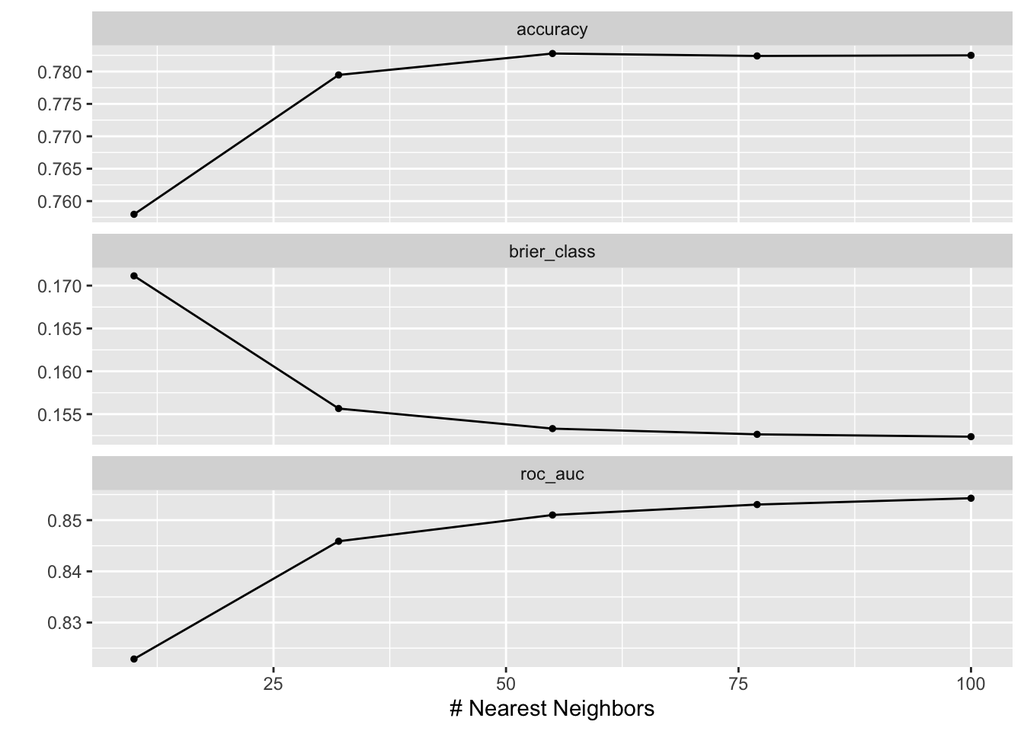

```r
autoplot(knn_tune)
```

- Our autoplot for the K-Nearest Neighbors model shows us a steady increase in model performance as the # of neighbors increases. Again, this goes back to the fact that with such a large data set it is viable to use a lot of nearby data points to make an educated classification decision with our model. However, we do see a general plateau in AUC-ROC score and accuracy as we reach 70 neighbors. Anything more than 100 neighbors would likely not contribute to a significant increase in model performance. A value of 100 for the neighbors parameter seems best for this model.

### SVM Tuning

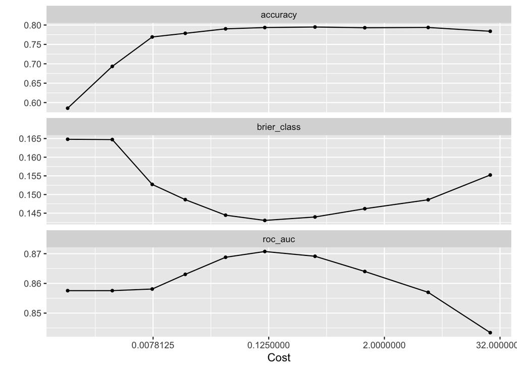

```r
autoplot(svm_tune)
```

- Finally, our SVM model does not show a huge difference in AUC-ROC score across the different values of the cost hyperparameter. Although the line graph seems to vary greatly in the AUC-ROC score plot, we are only working on a scale of 0.84 to 0.87. Nevertheless, the best performing model with an AUC-ROC score of 0.87 seems to be attained using a cost parameter of around 0.125.